# Data Science for Industry (STA5073Z)

Assignment 1

Author

Natalie Bianca Alexander

[output not shown]

[output cut: 64 more lines]

[output not shown]

```
# A tibble: 6 × 5
  filename                        speech                year  president_13 date
  <chr>                           <chr>                 <chr> <chr>        <chr>
1 1994_post_elections_Mandela.txt "24 May 1994  Madame… 1994  Mandela      24-0…
2 1994_pre_elections_deKlerk.txt  "28 February 1994  M… 1994  deKlerk      28-0…
3 1995_Mandela.txt                "17 February 1995  H… 1995  Mandela      17-0…
4 1996_Mandela.txt                "9 February 1996  Ho… 1996  Mandela      9-02…
5 1997_Mandela.txt                "7 February 1997  Ma… 1997  Mandela      7-02…
6 1998_Mandela.txt                "6 February 1998  Ma… 1998  Mandela      6-02…
```

```
# A tibble: 6 × 5
  filename                          speech              year  president_13 date
  <chr>                             <chr>               <chr> <chr>        <chr>
1 2019_post_elections_Ramaphosa.txt 20 Jun 2019 State … 2019  Ramaphosa    20-0…
2 2019_pre_elections_Ramaphosa.txt  7 Feb 2019 Speaker… 2019  Ramaphosa    7-02…
3 2020_Ramaphosa.txt                13 February 2020  … 2020  Ramaphosa    13-0…
4 2021_Ramaphosa.txt                11 February 2021  … 2021  Ramaphosa    11-0…
5 2022_Ramaphosa.txt                Thursday, 10 Febru… 2022  Ramaphosa    10-0…
6 2023_Ramaphosa.txt                Thursday, 10 Febru… 2023  Ramaphosa    10-0…
```

```
tibble [36 × 5] (S3: tbl_df/tbl/data.frame)
 $ filename    : chr [1:36] "1994_post_elections_Mandela.txt" "1994_pre_elections_deKlerk.txt" "1995_Mandela.txt" "1996_Mandela.txt" ...
 $ speech      : chr [1:36] "24 May 1994  Madame Speaker and Deputy Speaker, President of the Senate and Deputy President, Deputy Presidents"| __truncated__ "28 February 1994  Mr Speaker  This Parliament has convened to adopt important amendments to the Constitution of"| __truncated__ "17 February 1…
 $ year        : chr [1:36] "1994" "1994" "1995" "1996" ...
 $ president_13: chr [1:36] "Mandela" "deKlerk" "Mandela" "Mandela" ...
 $ date        : chr [1:36] "24-05-1994" "28-02-1994" "17-02-1995" "9-02-1996" ...
```

```
[1] "filename"     "speech"       "year"         "president_13" "date"
```

```
# A tibble: 6 × 2
# Groups:   president_label [6]
  president_label     n
  <chr>           <int>
1 Mandela             7
2 Mbeki              10
3 Motlanthe           1
4 Ramaphosa           7
5 Zuma               10
6 deKlerk             1
```

# 1 Abstract

# 2 Introduction

Text mining is a branch of artificial intelligence (AI) that aims to transform unstructured text data into structured formats (Ibm.com, 2023)<sup>1</sup>. Text mining employs a variety of statistical and machine learning methods, including Classification Trees, Random Forests, Naïve Bayesian models, and numerous other deep learning algorithms. These methods are used to uncover textual patterns, trends, and hidden relationships within unstructured data.

While traditional text mining relied solely on machine learning algorithms, modern text mining also employs sophisticated methods of Natural Language Processing (NLP) such as parsing and part-of-speech tagging (Greenbook.org, 2017)<sup>2</sup>. This advancement in text mining is largely attributed to the exponential growth in data, with approximately 80% of global data residing in unstructured formats. This vast amount of data has necessitated the use of text mining, making it a significant task in the field of data analytics.

The application of text mining is particularly useful in large organizations where decision-making is central and time is limiting (Ibm.com, 2023)<sup>1</sup>. For example, banks employ text mining in risk management to scrutinize changes in the sentiment of financial reports.

The many applications of text mining across various domains have led to the development of several models, including supervised, and unsupervised methods (Dogra et al., 2022)<sup>3</sup>. However, determining the most appropriate and effective model for a specific text mining task remains a complex and nuanced challenge.

The aim of this project is to identify the most effective classification model for authorship attribution, which involves determining the author of a given document (Mohamed Amine Boukhaled and Jean-Gabriel Ganascia, 2017)<sup>4</sup>. This project specifically focuses on analysing transcription text data from speeches delivered by South African presidents during the State of the Nation Address (SONA) from 1994 to 2023 (www.gov.za, 2023)<sup>5</sup>. SONA serves as an annual opening to South African Parliament, where the President reports on the socio-economic state of the nation to a joint sitting of Parliament. The main objective is to train a model that can take a sentence from a SONA speech and correctly predict which president said it.

# 3 Literature Review

Several studies have machine learning methods for author prediction. These techniques include Support Vector Machines (SVMs), Decision Trees, Random Forests (RF), and Neural Networks (NNs), to name a few. The choice of model often depends on the nature of the data and the specific requirements of the task.

Feature selection plays a crucial role in author prediction, where features are broadly categorized into lexical features (e.g., word usage) and syntactic features (e.g., part-of-speech tags). Some studies have also explored semantic features (e.g., topics and sentiments).

An article by Shukri, (2021)<sup>6</sup> suggests a method for author prediction, by training models on Arabic opinion articles. The study collected 8109 articles from 428 authors for the period 2016 to 2021. Their NN model achieved the highest accuracy of 81.1%.

Another article by Bauersfeld et al., (2023)<sup>7</sup> proposed a transformer-based, neural-network architecture that uses text content and author names in the bibliography to determine the author of an anonymous manuscript. The authors used all research papers publicly available on arXiv and achieved a 73% accuracy rate.

A similar paper by Khalid, (2021)<sup>8</sup> performed author prediction on 210 000 anonymous, news headlines from HuffPost (2012-2022). The study used Bag of Words (BoW) and Latent Semantic Analysis (LSA) features as input to train classification algorithms such as LR and RF. The study found that the LR model trained on all features outperformed all other models with an accuracy of 94.9%.

These manuscripts demonstrate the potential of text mining in various applications. These papers also highlight the variety of author-prediction techniques available, such as NN-, LR-, and RF- and SVM- models. However, we also note the challenges in applying these techniques, such as the need for large datasets, as well as the ability of these models to discriminate between content-related features and author-specific features.

# 4 Data

## 4.1 Data Source

The data set contains the speeches delivered by South African presidents during the State of the Nation Address (SONA) from 1994 to 2023. The data is publicly available on the South African government website (www.gov.za, 2023)<sup>5</sup>.

## 4.2 Data Description

Seven speeches are available for former president Mandela (1994-1999). Ten speeches are available for former president Mbeki (2000-2008). Ten speeches are also available for former president Zuma (2009-2017). President Ramaphosa has a total of seven speeches to date (2018-2023). Two outliers exist, namely one speech for former president deKlerk (1994) and former president Motlanthe (2009).

These records cumulatively formed the “sona” data set with 36 records and 5 variables, namely: *filename, speech, year, president* and *date of speech delivered*.

## 4.3 Data Pre-processing

All data was read into R version 4.3.1 , using R-Studio version 2023.9.1.494. The year of each speech was extracted from the first four characters in the “filename” column. The president names were extracted from the “filename” column using regular expressions, where alphabetical text ending in a “.txt” extension was matched as the presidents’ name. Subsequently, all other unnecessary text such as “http”-, fullstop-, ampersand-, greater-than-, and less-than characters were removed, in addition to trailing white spaces and new-line characters. Dates were then re-formatted into a *dd-mm-yyyy* format. Finally, the pre-processed data was saved as an RDS object for downstream analysis.

# 5 Methods

## 5.1 Data processing

The pre-processed data was read into R and converted to tibble format. The data was then assessed by looking at the head and tail of the tibble, in addition to looking at the data types of each column. Dates which appeared before a president’s speech were removed using regular expressions. Trailing white spaces before and after a president’s speech were also removed. I also noticed that former president- Motlanthe and deKlerk only had one record in comparison to the other presidents with more than one record, and so these observations were removed from the data set.

As a result, the processed data had 34 rows and 5 columns.

## 5.2 Tokenization

The processed sona data set was then tokenized into sentences using unnest_tokens(), since the goal is to make predictions on sentence inputs. All text was then converted to lowercase to remove word redundancy, where each word is treated as its own unique feature, irrespective of letter case. I also removed all punctuation so that root-words are treated alike*.* I then included a sentence id column to track sentence membership.

The sentence tokens were then tokenized into word and bigram tokens respectively, where all stop words were then removed. I also ensured that “blank” tokens were removed. For the tokenization by bigram implementation, bigrams were split into individual words, where each word was assessed for stop words. If a stop word was detected, the entire bigram was removed, while the remaining bigrams were unified.

## 5.3 Exploratory Data Analysis

I looked at the 20 most frequently used- words and bigrams: *(1)* for all presidents, and *(2)* for each president. I also looked at the average number of sentences per speech for a particular president. I then looked at the average number of words per sentence for a particular president.

## 5.4 Bag of Words Model

The machine learning models to be discussed implement the bag-of-words model (BoW). The BoW model computes the frequency of occurrence of an unordered collection of words and uses these frequencies as features to train the classifier.

A word bag was generated by taking the word tokens and grouping the unique sentence ID-president-word combinations and computing each grouping’s frequency, after which the top 200 words for each grouping was selected to create the final word bag. The choice of the top 200 most frequently occurring words was chosen due to its superior model performance relative to the top 100 and 500 words. The word bag consisted of 363 rows (words) and 3 columns (sentence ID, president, word).

The BoW was constructed by identifying all the words in a speech that overlap with the word bag. The frequency of a word within a sentence was then calculated. Finally, the BoW table was reformatted to a wide format (tidy format), where the column names are words (features), the rows are identified by the sentence ID and president name (observations) and the cell values are the frequency of a word within a sentence. All words not found in a sentence obtained a value of 0.

## 5.5 Term Frequency Inverse Document Frequency (TF-IDF) Model

Term Frequency – Inverse Document Frequency (TF-IDF) refers to the metric that describes how important a word is in a document relative to other documents in the corpus. The TF-IDF is calculated by multiplying the Term Frequency (TF) by the Inverse Document Frequency (IDF), where TF is frequency of occurrence of a word in a document divided by the total number of words in the document, whereas IDF is the proportion of documents in the corpus that contain the word.

The bind_tf_idf() function was used to calculate the TF-IDF for each word in each sentence. It is important to note the “document” here refers to the sentence ID. The BoW table previously discussed was then manipulated to include the TF-IDF instead of the frequency of the word.

## 5.7 Split Balanced Data into Training, Validation and Test sets

I partitioned the data into 70% training and 30% test sets using createDataPartition(), which performs stratified sampling. The target variable, *president* was then converted to factors, where classes: *Mandela, Mbeki, Ramaphosa* and *Zuma* were categorized as levels 1 to 4, respectively. For the validation set, 5-fold cross-validation was applied during training, which is discussed below.

## 5.8 Models

Each model (*a-e* below) was implemented for both the BoW and TF-IDF methods discussed above. For each model, a grid search was performed to find the optimal hyperparameters, generating sub-models as a result. For each of these sub-models, 5-fold cross-validation was performed on the training set. The best sub-model was determined by the model performance on both the training and validation sets. The hyperparameters of the best sub-model was then used to rebuild the model on the full training set, after which predictions were made on the test set. The final models were compared based on their test set performance. **Figure 1** below shows the general workflow.

#### a. Classification Tree

Classification trees are decision trees that recursively partition the input space and assign a class label to each partitioned region based on the majority class of the training samples in that region. A grid search was performed using the rpart() function with the following parameters:

- The complexity parameter, a stopping criterion where tree splitting terminates once the reduction in relative error is less than a specified *cp-threshold.*

**cp = {0.001, 0.112, 0.223, 0.334, 0.445, 0.556, 0.667, 0.778, 0.889, 1.000}**

- The minimum number of observations at any terminal node.

  **minbucket = {1, 2, 3, 4, 5, 6, 7, 8, 9, 10}**
- The minimum number of observations that must exist in a node for a split to be attempted.

  **minsplit= {1, 2, 3, 4, 5, 6, 7, 8, 9, 10}**

[output not shown]

**Figure 1:** Flow-chart showing the work-flow of model construction, hyperparameter tuning and model selection and testing after splitting the data into 70% training and 30% test sets.

In **Figure 1** above, the ribbons are the steps in the process and the rectangles are the choices made at that step.

## 5.9 Performance Metrics

For all models, performance on the training(folds-1), validation(fold), full training and test sets were determined by the metrics discussed below. For 5-fold cross-validation, the best sub-model was determined which had the best validation and training macro-average F1-score. The overall best model was also chosen based on the model with the best test set macro-average F1-score. Other metrics were also considered (see below).

When training a model with 5-fold cross-validation, each metric was determined at each fold for both the training and validation sets. At each fold, the metric is computed for every class, and the macro-average metric is obtained by averaging these class-specific metrics (**Equation 1**). After training is complete, the final metric is computed as the average of the macro-average metrics over all folds (**Equation 2**).

$$\text{MacroAverageMetric}_{\text{fold}} = \frac{1}{n} \sum_{i=1}^{n} \text{metric}_{i,\text{fold}}$$

*…equation 1*, where metric<sub>i, fold</sub> is the metric for class i at a specific fold, and n is the number of classes.

$$\text{FinalMetric} = \frac{1}{k} \sum_{j=1}^{k} \text{MacroAverageMetric}_{j}$$

*…equation 2*, where MacroAverageMetric<sub>j</sub> is the macro-average metric at fold j, and k is the total number of folds.

#### a. Accuracy

This is the proportion of correct classifications among the total number of classifications. The formula is shown in **Equation 3** below:

$$\text{Accuracy} = \frac{(\text{TP} + \text{TN})}{(\text{TP} + \text{TN} + \text{FP} + \text{FN})}$$

*…equation 3,* where TP, TN, FP and FN are the number of true positives, true negatives, false positives, and false negatives, respectively found in the confusion matrix.

#### b. Recall

Also known as the sensitivity or true positive rate, this is the proportion of actual positives that are correctly classified.

$$\text{Recall} = \frac{\text{TP}}{(\text{TP} + \text{FN})}$$
*…equation 4*

#### c. Precision

Also known as the positive predictive value, this is the proportion of positive predictions that are actually correctly classified.

$$\text{Precision} = \frac{\text{TP}}{(\text{TP} + \text{FP})}$$
*…equation 5*

#### d. F1-score

This is a measure that combines precision and recall using the harmonic mean, by obtaining a balance of precision and recall.

$$F1 = 2 \frac{(\text{Precision} \times \text{Recall})}{(\text{Precision} + \text{Recall})}$$
*…equation 6*

# 6 Results & Discussion

## 6.1 a. Exploratory Data Analysis

#### a. Top 20 most frequent words and bigrams

**Figure 2** below shows the top 20 most frequently used words and bigrams among all presidents. The bigrams provide more context relative to the unigrams, and we see that most president’s agenda is about economic growth with bigrams such as “economic growth”, “job creation” and “economic empowerment”. **Figure 3** below shows the top 20 most frequently used words for each president and **Figure 4** below shows the top 20 most frequently used bigrams for each president. In these figures we see that the agenda is more specific to that year or that president, where Mandela has bigrams such as “people-centered society” alluding to the end of Apartheid, Mbeki focuses on social justice with bigrams such as “social security” and “social partners”, Zuma focuses on the “world cup” which alludes to the 2010 soccer world cup hosted in South Africa and Ramaphosa’s focus is on crime prevention with bigrams such as “gender-based violence” and “law enforcement”.

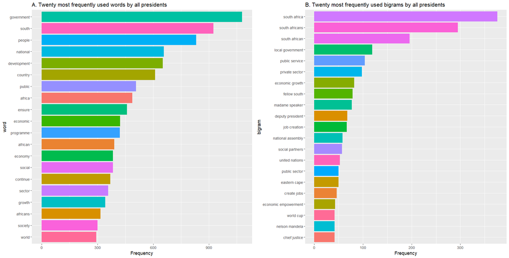

Figure 2: Bar plots showing the top 20 most frequently used word and bigrams among all presidents

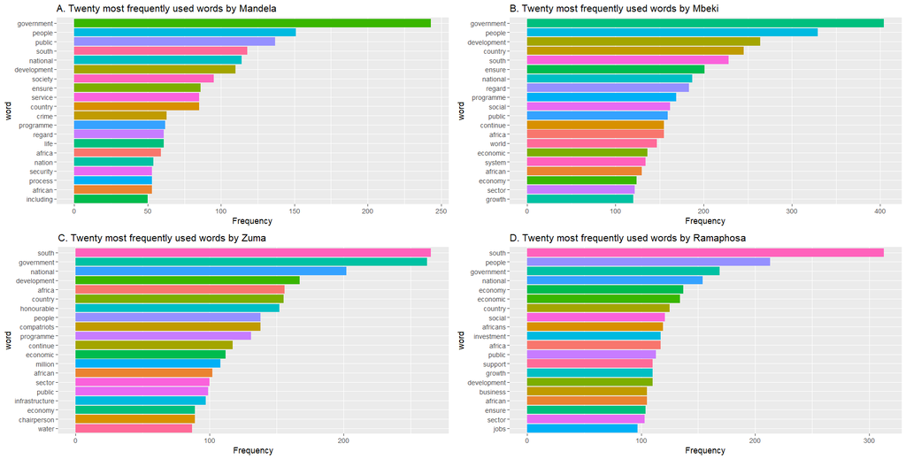

**Figure 3:** Bar plots showing the top 20 most frequently used words by each president

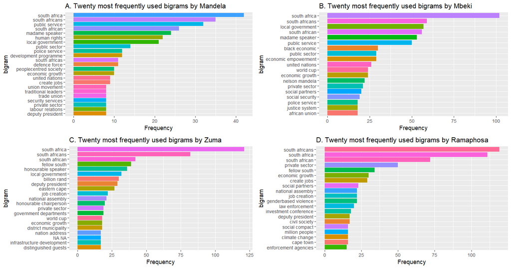

Figure 4: Bar plots showing the top 20 most frequently used bigrams by each president

#### b. Average speech and sentence length

**Figure 5** below shows the average speech length per president (a) and the average sentence length per president (b). In **Figure 5 (a)** we see that Ramaphosa has a relatively longer average speech length, in other words the average number of sentences within a speech is quite long for Ramaphosa. All other presidents have relatively the same average speech length. In **Figure 5 (b)** we see that Mbeki has the largest average sentence length (average number of words per sentence), followed by Mandela, Ramaphosa and Zuma.

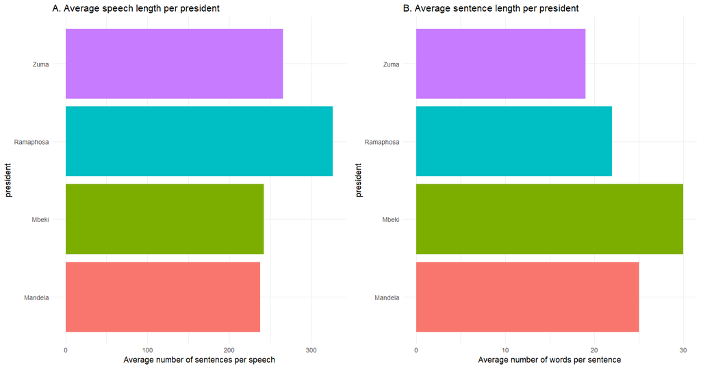

**Figure 5:** Bar plots showing the average speech length per president and the average sentence length per president

# 7 Conclusion

In EDA (**Figure 5** above), we see differences in the average number of words used in a sentence for each president,this might be useful to include as a feature when training the models.

# 8 References

1. Ibm.com. (2023). *What is Text Mining? | IBM*. [online] Available at: https://www.ibm.com/. [Accessed 14 Oct. 2023].

2. Greenbook.org. (2017). *Text Analytics: A Primer*. [online] Available at: https://www.greenbook.org/insights/market-research-leaders/text-analytics-a-primer [Accessed 14 Oct. 2023].

3. Dogra, V., Verma, S., Kavita Kavita, Chatterjee, P., Shafi, J., Choi, J. and Muhammad Fazal Ijaz (2022). A Complete Process of Text Classification System Using State-of-the-Art NLP Models. Computational Intelligence and Neuroscience, [online] 2022, pp.1–26. doi:https://doi.org/10.1155/2022/1883698.

4. Mohamed Amine Boukhaled and Jean-Gabriel Ganascia (2017). Stylistic Features Based on Sequential Rule Mining for Authorship Attribution. [online] doi:https://doi.org/10.1016/b978-1-78548-253-3.50008-1.

5. www.gov.za. (2023). *State of the Nation Address | South African Government*. [online] Available at: https://www.gov.za/state-nation-address [Accessed 14 Oct. 2023].

6. Shukri, N. (2021). Author Prediction in Text Mining of the Opinion Articles in Arabic Newspapers. [online] 16(2), pp.1-05. doi:https://doi.org/10.9790/2834-1602020105.

7. Bauersfeld, L., Romero, A., Manasi Muglikar and Davide Scaramuzza (2023). Cracking double-blind review: Authorship attribution with deep learning. PLOS ONE, [online] 18(6), pp.e0287611–e0287611. doi: https://doi.org/10.1371/journal.pone.0287611.

8. Khalid, N. (2021). AUTHOR IDENTIFICATION BASED ON NLP. *European Journal of Computer Science and Information Technology*, [online] 9(1), pp.1–26. Available at: https://www.eajournals.org/wp-content/uploads/Author-Identification-Based-on-NLP.pdf.